# Table of Contents

## Load and clean the dataset

```python
# set working directory
import os
os.chdir("D:\\ESSEC\\Machine learning\\project-airbnb\\airbnb-price-prediction")
# load the dataset
import pandas as pd
import numpy as np
df = pd.read_csv("airbnb_price.csv")
df = df.drop("Unnamed: 0",axis=1)
df.head()
```

|  | id | log_price | property_type | room_type | amenities | accommodates | bathrooms | bed_type | cancellation_policy | cleaning_fee | ... | latitude | longitude | name | neighbourhood | number_of_reviews | review_scores_rating | thumbnail_url | zipcode | bedrooms | beds |
| --- | --- | --- | --- | --- | --- | --- | --- | --- | --- | --- | --- | --- | --- | --- | --- | --- | --- | --- | --- | --- | --- |
| 0 | 6304928 | 5.129899 | Apartment | Entire home/apt | {"Wireless Internet","Air conditioning",Kitche... | 7 | 1.0 | Real Bed | strict | True | ... | 40.766115 | -73.989040 | Superb 3BR Apt Located Near Times Square | Hell's Kitchen | 6 | 93.0 | https://a0.muscache.com/im/pictures/348a55fe-4... | 10019 | 3.0 | 3.0 |
| 1 | 7919400 | 4.976734 | Apartment | Entire home/apt | {TV,"Cable TV","Wireless Internet","Air condit... | 5 | 1.0 | Real Bed | moderate | True | ... | 40.808110 | -73.943756 | The Garden Oasis | Harlem | 10 | 92.0 | https://a0.muscache.com/im/pictures/6fae5362-9... | 10027 | 1.0 | 3.0 |
| 2 | 5578513 | 4.605170 | Apartment | Private room | {Internet,"Wireless Internet","Air conditionin... | 2 | 1.0 | Real Bed | strict | True | ... | 40.723883 | -73.983880 | Large East Village Bedroom To Let! | Alphabet City | 82 | 93.0 | https://a0.muscache.com/im/pictures/21726900/1... | 10009.0 | 1.0 | 1.0 |
| 3 | 18224863 | 4.595120 | House | Entire home/apt | {TV,"Wireless Internet","Air conditioning",Kit... | 8 | 1.0 | Real Bed | strict | True | ... | 40.643773 | -73.950855 | 3 Bedroom Apartment for Small Group or Family | Flatbush | 5 | 72.0 | https://a0.muscache.com/im/pictures/e9baba99-e... | 11226.0 | 3.0 | 3.0 |
| 4 | 16679342 | 3.688879 | House | Private room | {Internet,"Air conditioning",Kitchen,"Smoking ... | 2 | 1.5 | Real Bed | strict | True | ... | 40.656278 | -73.922645 | THE LIBRARY LOUNGE | East Flatbush | 57 | 89.0 | https://a0.muscache.com/im/pictures/58fcc67e-4... | 11212.0 | 1.0 | 1.0 |

5 rows × 29 columns

```python
# check the size of the data frame
df.shape
```

```
(17856, 29)
```

```python
# check the data structure
df.info()
```

```
<class 'pandas.core.frame.DataFrame'>
RangeIndex: 17856 entries, 0 to 17855
Data columns (total 29 columns):
id                        17856 non-null int64
log_price                 17856 non-null float64
property_type             17856 non-null object
room_type                 17856 non-null object
amenities                 17856 non-null object
accommodates              17856 non-null int64
bathrooms                 17856 non-null float64
bed_type                  17856 non-null object
cancellation_policy       17856 non-null object
cleaning_fee              17856 non-null bool
city                      17856 non-null object
description               17856 non-null object
first_review              17856 non-null object
host_has_profile_pic      17856 non-null object
host_identity_verified    17856 non-null object
host_response_rate        17856 non-null object
host_since                17856 non-null object
instant_bookable          17856 non-null object
last_review               17856 non-null object
latitude                  17856 non-null float64
longitude                 17856 non-null float64
name                      17856 non-null object
neighbourhood             17856 non-null object
number_of_reviews         17856 non-null int64
review_scores_rating      17856 non-null float64
thumbnail_url             17856 non-null object
zipcode                   17856 non-null object
bedrooms                  17856 non-null float64
beds                      17856 non-null float64
dtypes: bool(1), float64(7), int64(3), object(18)
memory usage: 3.8+ MB
```

```python
# find records with unusual price
problem = df[df["log_price"] < 2]
problem
```

|  | id | log_price | property_type | room_type | amenities | accommodates | bathrooms | bed_type | cancellation_policy | cleaning_fee | ... | latitude | longitude | name | neighbourhood | number_of_reviews | review_scores_rating | thumbnail_url | zipcode | bedrooms | beds |
| --- | --- | --- | --- | --- | --- | --- | --- | --- | --- | --- | --- | --- | --- | --- | --- | --- | --- | --- | --- | --- | --- |
| 929 | 4822822 | 1.609438 | Apartment | Entire home/apt | {"Wireless Internet","Air conditioning",Kitche... | 2 | 1.0 | Real Bed | flexible | True | ... | 40.782207 | -73.973961 | Upper West Side Studio Steps from Central Park | Upper West Side | 1 | 100.0 | https://a0.muscache.com/im/pictures/2d9bc994-a... | 10024 | 0.0 | 1.0 |
| 2804 | 17972519 | 0.000000 | Condominium | Shared room | {TV,"Wireless Internet","Air conditioning",Kit... | 1 | 1.0 | Real Bed | strict | True | ... | 40.838054 | -73.858665 | Esteem's Place | Parkchester | 3 | 87.0 | https://a0.muscache.com/im/pictures/71bc085f-b... | 10462 | 1.0 | 1.0 |

2 rows × 29 columns

```python
# Obviously, the price 0 makes no sense, so delete the outlier
df = df.drop([2804],axis=0)
```

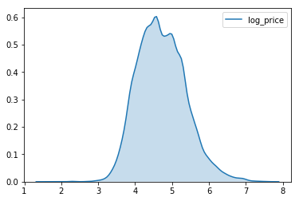

```python
# visualize the distribution of target value
import seaborn as sns
sns.kdeplot(df["log_price"], shade=True)
```

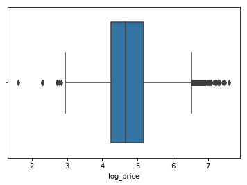

```python
sns.boxplot(df['log_price'])
```

## Feature engineering

### Amenities

We split the amenities by comma, classify the value into 3 new category and count the frequency of word for each 3 category for each row. Thus we created 3 new features: functionality, thoughtfulness and special.

```python
# Extract amenities
amenity = df['amenities']
amenity[1]
```

```
'{TV,"Cable TV","Wireless Internet","Air conditioning",Kitchen,Breakfast,"Buzzer/wireless intercom",Heating,"Family/kid friendly","Smoke detector","Carbon monoxide detector","Fire extinguisher",Essentials,Shampoo,Hangers,"Hair dryer",Iron,"Laptop friendly workspace","translation missing: en.hosting_…
```

```python
amenity = amenity.str.lstrip('{')
amenity = amenity.str.rstrip('}')
amenity = amenity.str.replace('"','')
# separate by comma and get a dataframe
amenity = amenity.str.split(",",expand=True)
```

```python
amenity.head()
```

|  | 0 | 1 | 2 | 3 | 4 | 5 | 6 | 7 | 8 | 9 | ... | 67 | 68 | 69 | 70 | 71 | 72 | 73 | 74 | 75 | 76 |
| --- | --- | --- | --- | --- | --- | --- | --- | --- | --- | --- | --- | --- | --- | --- | --- | --- | --- | --- | --- | --- | --- |
| 0 | Wireless Internet | Air conditioning | Kitchen | Heating | Family/kid friendly | Washer | Dryer | Smoke detector | Fire extinguisher | Essentials | ... | None | None | None | None | None | None | None | None | None | None |
| 1 | TV | Cable TV | Wireless Internet | Air conditioning | Kitchen | Breakfast | Buzzer/wireless intercom | Heating | Family/kid friendly | Smoke detector | ... | None | None | None | None | None | None | None | None | None | None |
| 2 | Internet | Wireless Internet | Air conditioning | Kitchen | Pets allowed | Buzzer/wireless intercom | Heating | Washer | Dryer | Smoke detector | ... | None | None | None | None | None | None | None | None | None | None |
| 3 | TV | Wireless Internet | Air conditioning | Kitchen | Breakfast | Heating | Smoke detector | Fire extinguisher | Essentials | Lock on bedroom door | ... | None | None | None | None | None | None | None | None | None | None |
| 4 | Internet | Air conditioning | Kitchen | Smoking allowed | Pets live on this property | Dog(s) | Heating | Smoke detector | Fire extinguisher | translation missing: en.hosting_amenity_49 | ... | None | None | None | None | None | None | None | None | None | None |

5 rows × 77 columns

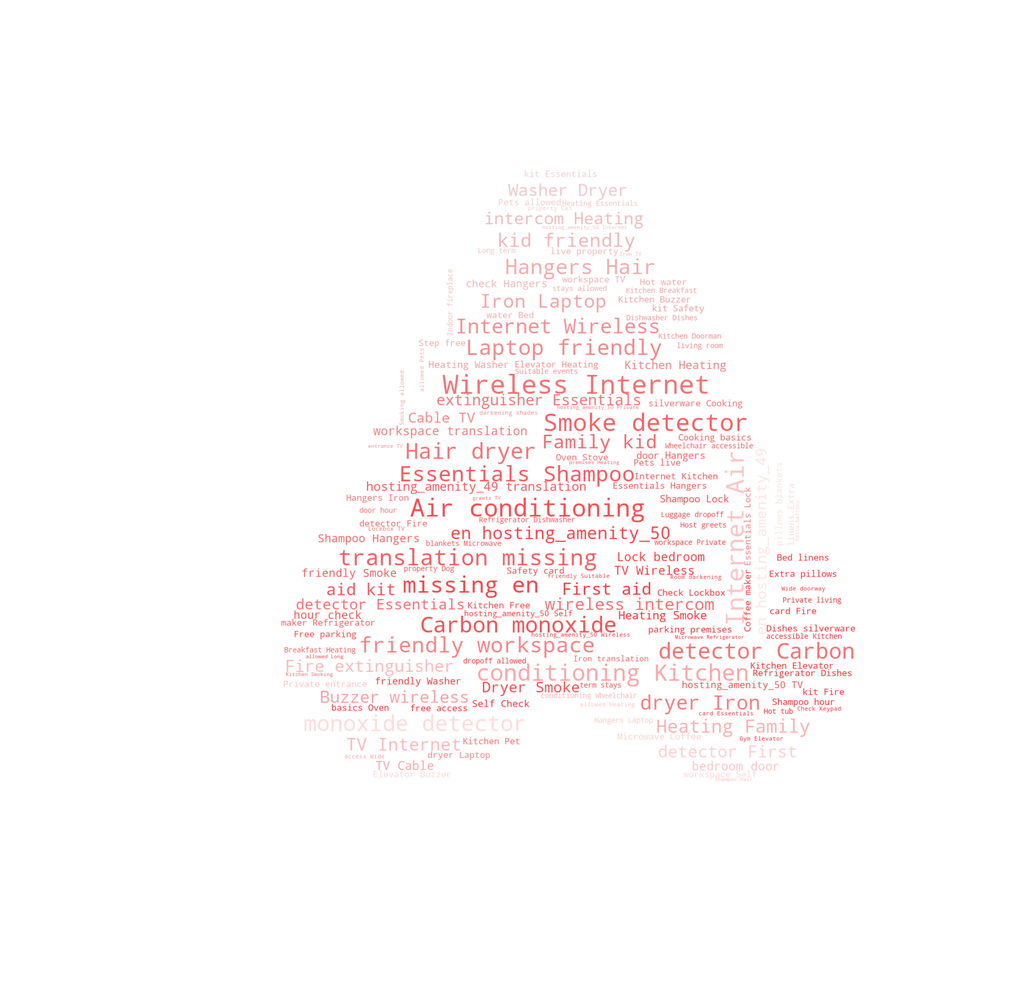

```python
# Draw a wordcloud using amenities
from wordcloud import WordCloud
from PIL import Image
import matplotlib.pyplot as plt
from wordcloud import ImageColorGenerator

f = open('amenity.txt','r').read()
air_color = np.array(Image.open('airbnb.png'))
i_color = ImageColorGenerator(air_color)
wc = WordCloud(background_color="white", max_words=150,max_font_size=50,mask=air_color)
wc.generate(f)
plt.figure(dpi=1024)
plt.imshow(wc.recolor(color_func=i_color), interpolation="bilinear")
plt.axis("off")
plt.show()
```

As we can see from the wordcloud, the frequency of each amenity shows huge difference and the frequently appeared amenities tend to be the basic needs and the less frequently appeared ones may have more added-value to the price.

```python
# import the dataset for classification: match the amenity dataframe with 3 categories
cate_a = pd.read_csv("Amenities-by-category.csv")
cate_a.head()
```

|  | Amenities | Category |
| --- | --- | --- |
| 0 | Wireless Internet | Fundationality |
| 1 | Air conditioning | Fundationality |
| 2 | Kitchen | Fundationality |
| 3 | Heating | Fundationality |
| 4 | Dryer | Fundationality |

```python
# delete the space in amenities text
cate_a.Amenities = cate_a.Amenities.str.strip()
```

```python
# create a dictionary: key = amenities, value = category
Amenities_Dict = dict(zip(cate_a.Amenities, cate_a.Category))
```

```python
# transfer the amenity dataset to category
for i in range(amenity.shape[1]):
    amenity.iloc[:,i] = amenity.iloc[:,i].map(Amenities_Dict)
```

```python
amenity.head()
```

|  | 0 | 1 | 2 | 3 | 4 | 5 | 6 | 7 | 8 | 9 | ... | 67 | 68 | 69 | 70 | 71 | 72 | 73 | 74 | 75 | 76 |
| --- | --- | --- | --- | --- | --- | --- | --- | --- | --- | --- | --- | --- | --- | --- | --- | --- | --- | --- | --- | --- | --- |
| 0 | Fundationality | Fundationality | Fundationality | Fundationality | Special | Thoughtfulness | Fundationality | Thoughtfulness | Special | Fundationality | ... | NaN | NaN | NaN | NaN | NaN | NaN | NaN | NaN | NaN | NaN |
| 1 | Thoughtfulness | Thoughtfulness | Fundationality | Fundationality | Fundationality | Thoughtfulness | Fundationality | Fundationality | Special | Thoughtfulness | ... | NaN | NaN | NaN | NaN | NaN | NaN | NaN | NaN | NaN | NaN |
| 2 | Fundationality | Fundationality | Fundationality | Fundationality | Special | Fundationality | Fundationality | Thoughtfulness | Fundationality | Thoughtfulness | ... | NaN | NaN | NaN | NaN | NaN | NaN | NaN | NaN | NaN | NaN |
| 3 | Thoughtfulness | Fundationality | Fundationality | Fundationality | Thoughtfulness | Fundationality | Thoughtfulness | Special | Fundationality | Thoughtfulness | ... | NaN | NaN | NaN | NaN | NaN | NaN | NaN | NaN | NaN | NaN |
| 4 | Fundationality | Fundationality | Fundationality | Special | Special | Special | Fundationality | Thoughtfulness | Special | NaN | ... | NaN | NaN | NaN | NaN | NaN | NaN | NaN | NaN | NaN | NaN |

5 rows × 77 columns

```python
# count the frequency of 3 categories in each row
func = []
thought = []
special = []
for i in range(amenity.shape[0]):
    func.append(amenity.iloc[i,:].str.count('Fundationality').sum())
    thought.append(amenity.iloc[i,:].str.count('Thoughtfulness').sum())
    special.append(amenity.iloc[i,:].str.count('Special').sum())

# create new feature columns
df['Functionality'] = func
df['Thoughtfulness'] = thought
df['Special'] = special
```

### Property type

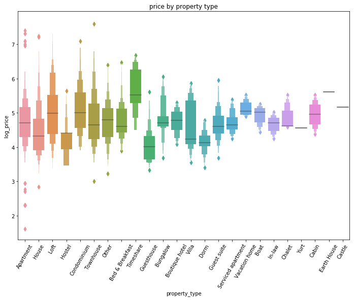

```python
import matplotlib.pyplot as plt
fig, ax = plt.subplots(figsize=(11.7,8.27))
g1 = sns.boxenplot(ax=ax,x='property_type', y='log_price', data=df)
g1.set_title('price by property type')
g1.set_xticklabels(g1.get_xticklabels(),rotation=60)
plt.show()
```

The distribution of each property type is very unique, especially for the properties with few records, group the property will lose some information, so we keep the variable and want to check the performance in model afterwards.

### New feature: active number of review per month

```python
df['first_review'] = pd.to_datetime(df['first_review'])
df['host_since'] = pd.to_datetime(df['host_since'])
df['last_review'] = pd.to_datetime(df['last_review'])
```

```python
# function to calculate the diff of month
def diff_month(d2,d1):
    import datetime
    from dateutil import rrule
    months = rrule.rrule(rrule.MONTHLY, dtstart=d1, until=d2).count()
    return months
```

```python
D2 = df['last_review'].tolist()
D1 = df['first_review'].tolist()
review_mth = []
for i in range(len(D2)):
    review_mth.append(diff_month(D2[i],D1[i]))
```

```python
df["review_mth"] = review_mth
```

```python
# calculate the number of review per month
df["nreview_mth"] = df["number_of_reviews"]/df["review_mth"]
```

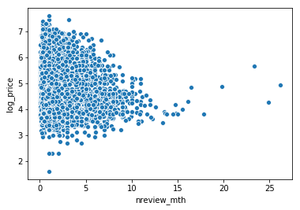

```python
# visualize the data
sns.scatterplot(x="nreview_mth", y="log_price", data=df)
```

### New feature: borough

Here we found another dataset which divides NYC neighbourhood into 5 boroughs and it helps to extract information from neighbourhood which contains more than 100 unique values.

```python
bo_nei = pd.read_csv("neighbourhood.csv")
df = df.merge(bo_nei,on='neighbourhood',how='left')
```

```python
df.borough.isna().sum()
```

```
0
```

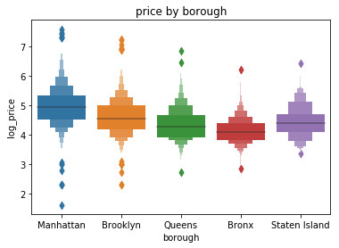

```python
# visualize the data
fig, ax = plt.subplots()
g = sns.boxenplot(ax=ax,x='borough', y='log_price', data=df)
title_name = 'price by '+ 'borough'
g.set_title(title_name)
plt.show()
fig = g.get_figure()
fig.savefig("borough.png")
```

### Other categorical values

```python
df.select_dtypes(include='object').describe()
```

|  | property_type | room_type | amenities | bed_type | cancellation_policy | city | description | first_review | host_has_profile_pic | host_identity_verified | host_response_rate | host_since | instant_bookable | last_review | name | neighbourhood | thumbnail_url | zipcode |
| --- | --- | --- | --- | --- | --- | --- | --- | --- | --- | --- | --- | --- | --- | --- | --- | --- | --- | --- |
| count | 17855 | 17855 | 17855 | 17855 | 17855 | 17855 | 17855 | 17855 | 17855 | 17855 | 17855 | 17855 | 17855 | 17855 | 17855 | 17855 | 17855 | 17855 |
| unique | 24 | 3 | 16950 | 5 | 5 | 1 | 17723 | 2112 | 2 | 2 | 66 | 2787 | 2 | 727 | 17753 | 193 | 17853 | 260 |
| top | Apartment | Entire home/apt | {} | Real Bed | strict | NYC | Welcome to RMH, a co-ed hostel vibe home for e... | 2017-09-04 | t | t | 100% | 2014-11-02 | f | 2017-09-24 | Spacious Private Room in Brooklyn | Williamsburg | https://a0.muscache.com/im/pictures/61042471/5... | 11221 |
| freq | 14559 | 9097 | 31 | 17338 | 9734 | 17855 | 6 | 150 | 17827 | 12216 | 14186 | 23 | 12544 | 991 | 5 | 1523 | 2 | 727 |

```python
# 3 variables with value f and t: change them to numerical values 0 and 1

df["host_has_profile_pic"] = df["host_has_profile_pic"].map({'f':0,'t':1})
df["host_identity_verified"] = df["host_identity_verified"].map({'f':0,'t':1})
df["instant_bookable"] = df["instant_bookable"].map({'f':0,'t':1})
```

```python
# host response rate is actually numerical value
df["host_response_rate"] = df["host_response_rate"].str.strip("%").astype(float)/100
```

### Numeric value

```python
# change bool to int
df["cleaning_fee"] = df["cleaning_fee"].astype('int')
```

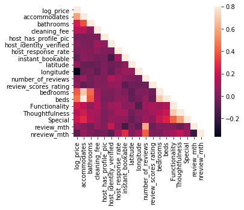

```python
numeric_data2 = df._get_numeric_data()
# heatmap with correlation matrix
num2 = numeric_data2.drop('id',axis=1)
corrMat = num2.corr()
mask = np.array(corrMat)
mask[np.tril_indices_from(mask)] = False
ax = sns.heatmap(corrMat,mask=mask,vmax=.8, square = True)
```

## Filter the features for initial model

```python
drop_col = ["id","amenities","description","first_review","host_since","last_review","name",
            "neighbourhood","number_of_reviews","thumbnail_url","zipcode","review_mth","city","latitude","longitude"]
model_df = df.drop(drop_col,axis=1)
```

```python
model_df.head()
```

|  | log_price | property_type | room_type | accommodates | bathrooms | bed_type | cancellation_policy | cleaning_fee | host_has_profile_pic | host_identity_verified | host_response_rate | instant_bookable | review_scores_rating | bedrooms | beds | Functionality | Thoughtfulness | Special | nreview_mth | borough |
| --- | --- | --- | --- | --- | --- | --- | --- | --- | --- | --- | --- | --- | --- | --- | --- | --- | --- | --- | --- | --- |
| 0 | 5.129899 | Apartment | Entire home/apt | 7 | 1.0 | Real Bed | strict | 1 | 1 | 0 | 1.0 | 1 | 93.0 | 3.0 | 3.0 | 9.0 | 3.0 | 2.0 | 3.000000 | Manhattan |
| 1 | 4.976734 | Apartment | Entire home/apt | 5 | 1.0 | Real Bed | moderate | 1 | 1 | 1 | 1.0 | 1 | 92.0 | 1.0 | 3.0 | 10.0 | 5.0 | 3.0 | 2.000000 | Manhattan |
| 2 | 4.605170 | Apartment | Private room | 2 | 1.0 | Real Bed | strict | 1 | 1 | 1 | 1.0 | 0 | 93.0 | 1.0 | 1.0 | 11.0 | 2.0 | 1.0 | 1.906977 | Manhattan |
| 3 | 4.595120 | House | Entire home/apt | 8 | 1.0 | Real Bed | strict | 1 | 1 | 0 | 1.0 | 1 | 72.0 | 3.0 | 3.0 | 15.0 | 8.0 | 1.0 | 2.500000 | Brooklyn |
| 4 | 3.688879 | House | Private room | 2 | 1.5 | Real Bed | strict | 1 | 1 | 1 | 1.0 | 0 | 89.0 | 1.0 | 1.0 | 4.0 | 1.0 | 4.0 | 2.375000 | Brooklyn |

```python
model_df.shape
```

```
(17855, 20)
```

```python
# create dummy variables
df_final = pd.get_dummies(model_df)
```

```python
df_final.info()
```

```
<class 'pandas.core.frame.DataFrame'>
Int64Index: 17855 entries, 0 to 17854
Data columns (total 57 columns):
log_price                              17855 non-null float64
accommodates                           17855 non-null int64
bathrooms                              17855 non-null float64
cleaning_fee                           17855 non-null int32
host_has_profile_pic                   17855 non-null int64
host_identity_verified                 17855 non-null int64
host_response_rate                     17855 non-null float64
instant_bookable                       17855 non-null int64
review_scores_rating                   17855 non-null float64
bedrooms                               17855 non-null float64
beds                                   17855 non-null float64
Functionality                          17855 non-null float64
Thoughtfulness                         17855 non-null float64
Special                                17855 non-null float64
nreview_mth                            17855 non-null float64
property_type_Apartment                17855 non-null uint8
property_type_Bed & Breakfast          17855 non-null uint8
property_type_Boat                     17855 non-null uint8
property_type_Boutique hotel           17855 non-null uint8
property_type_Bungalow                 17855 non-null uint8
property_type_Cabin                    17855 non-null uint8
property_type_Castle                   17855 non-null uint8
property_type_Chalet                   17855 non-null uint8
property_type_Condominium              17855 non-null uint8
property_type_Dorm                     17855 non-null uint8
property_type_Earth House              17855 non-null uint8
property_type_Guest suite              17855 non-null uint8
property_type_Guesthouse               17855 non-null uint8
property_type_Hostel                   17855 non-null uint8
property_type_House                    17855 non-null uint8
property_type_In-law                   17855 non-null uint8
property_type_Loft                     17855 non-null uint8
property_type_Other                    17855 non-null uint8
property_type_Serviced apartment       17855 non-null uint8
property_type_Timeshare                17855 non-null uint8
property_type_Townhouse                17855 non-null uint8
property_type_Vacation home            17855 non-null uint8
property_type_Villa                    17855 non-null uint8
property_type_Yurt                     17855 non-null uint8
room_type_Entire home/apt              17855 non-null uint8
room_type_Private room                 17855 non-null uint8
room_type_Shared room                  17855 non-null uint8
bed_type_Airbed                        17855 non-null uint8
bed_type_Couch                         17855 non-null uint8
bed_type_Futon                         17855 non-null uint8
bed_type_Pull-out Sofa                 17855 non-null uint8
bed_type_Real Bed                      17855 non-null uint8
cancellation_policy_flexible           17855 non-null uint8
cancellation_policy_moderate           17855 non-null uint8
cancellation_policy_strict             17855 non-null uint8
cancellation_policy_super_strict_30    17855 non-null uint8
cancellation_policy_super_strict_60    17855 non-null uint8
borough_Bronx                          17855 non-null uint8
borough_Brooklyn                       17855 non-null uint8
borough_Manhattan                      17855 non-null uint8
borough_Queens                         17855 non-null uint8
borough_Staten Island                  17855 non-null uint8
dtypes: float64(10), int32(1), int64(4), uint8(42)
memory usage: 3.5 MB
```

## Modeling

```python
# Split train set and test set
from sklearn.model_selection import train_test_split
X = df_final.drop("log_price",axis=1)
y = df_final["log_price"]
X_train, X_test, y_train, y_test = train_test_split(X, y, test_size=0.2, random_state=42)
```

### Linear regression

```python
from sklearn.linear_model import LinearRegression
from sklearn.metrics import mean_squared_error

reg = LinearRegression().fit(X_train, y_train)

y_pred = reg.predict(X_test)
mse = mean_squared_error(y_test, y_pred)
print("mse: {}".format(mse))
print("train set accuracy: {}".format(reg.score(X_train, y_train)))
print("test set accuracy: {}".format(reg.score(X_test,y_test)))
```

```
mse: 0.13231465303935372
train set accuracy: 0.674451245080864
test set accuracy: 0.6933070199365716
```

### Ridge regression

```python
# pick the best alpha
from sklearn.linear_model import Ridge
MSE =[]
R2 = []
train_acc = []
Alpha = []
for alpha in np.arange(1,50,1):
    Alpha.append(alpha)
    clf = Ridge(alpha)
    clf.fit(X_train,y_train)
    train_acc.append(clf.score(X_train,y_train))
    R2.append(clf.score(X_test, y_test))
    y_pred = clf.predict(X_test)
    MSE.append(mean_squared_error(y_test,y_pred))
```

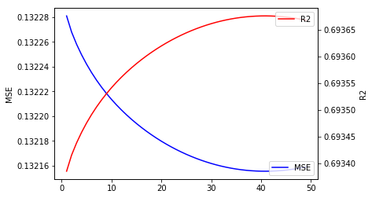

```python
fig = plt.figure()
ax1 = fig.add_subplot(111)
ax1.plot(np.arange(1,50,1), MSE, 'b', label='MSE')
ax1.set_ylabel('MSE')
ax1.legend(loc='lower right')
ax2 = ax1.twinx()
ax2.plot(np.arange(1,50,1), R2, 'r', label='R2')
ax2.set_ylabel('R2')
ax2.legend(loc='upper right')
plt.xlabel('alpha')
plt.show()
```

```python
# alpha with the highest score and lowest mse
print("alpha with highest test accuracy: {}".format(Alpha[R2.index(max(R2))]))
print("alpha with lowest mse: {}".format(Alpha[MSE.index(min(MSE))]))
```

```
alpha with highest test accuracy: 41
alpha with lowest mse: 41
```

```python
# print the evaluation
print("mse: {}".format(min(MSE)))
print("train set accuracy: {}".format(train_acc[R2.index(max(R2))]))
print("test set accuracy: {}".format(max(R2)))
```

```
mse: 0.1321553905278875
train set accuracy: 0.6731547398307577
test set accuracy: 0.6936761755299393
```

### Lasso regression

```python
from sklearn import linear_model
MSE_l =[]
R2_l = []
Train_l = []
Al = []
for alpha in np.arange(0.01,0.1,0.01):
    Al.append(alpha)
    clf2 = linear_model.Lasso(alpha)
    clf2.fit(X_train,y_train)
    Train_l.append(clf2.score(X_train,y_train))
    R2_l.append(clf2.score(X_test, y_test))
    y_pred = clf2.predict(X_test)
    MSE_l.append(mean_squared_error(y_test,y_pred))
```

```python
# print the evaluation
print("mse: {}".format(MSE_l[R2_l.index(max(R2_l))]))
print("train set accuracy: {}".format(Train_l[R2_l.index(max(R2_l))]))
print("test set accuracy: {}".format(max(R2_l)))
```

```
mse: 0.1398393294406592
train set accuracy: 0.645352736063866
test set accuracy: 0.6758655244066476
```

The accuracy of the lasso model is low

### Support vector regression

```python
from sklearn.svm import SVR
sv = SVR()
sv.fit(X_train,y_train)
sv.score(X_train,y_train)
y_pred = sv.predict(X_test)
mse = mean_squared_error(y_test, y_pred)
print("mse: {}".format(mse))
print("train set accuracy: {}".format(sv.score(X_train, y_train)))
print("test set accuracy: {}".format(sv.score(X_test,y_test)))
```

```
mse: 0.12777363220336466
train set accuracy: 0.7325985849373249
test set accuracy: 0.7038326811594853
```

### Random forest regression

```python
from scipy.stats import randint
from sklearn.model_selection import RandomizedSearchCV
from sklearn.ensemble import RandomForestRegressor

# Use randomized search cv to initialize the parameter
# Setup the parameters and distributions to sample from: param_dist
param_dist = {"n_estimators": randint(10,100),
              "max_depth": randint(1,20),
             "max_features": randint(1,20)}
rf = RandomForestRegressor()
# Instantiate the RandomizedSearchCV object
rf_cv = RandomizedSearchCV(rf, param_dist, cv=5)

# Fit the data
rf_cv.fit(X_train,y_train)
print("Optimized random forest parameters: {}".format(rf_cv.best_params_))
```

```
Optimized random forest parameters: {'max_depth': 17, 'max_features': 6, 'n_estimators': 92}
```

```python
# Prediction for the test
y_pred = rf_cv.predict(X_test)
mse = mean_squared_error(y_test, y_pred)

print("mse: {}".format(mse))
print("Accuracy on train set: {}".format(rf_cv.score(X_train,y_train)))
print("Accuracy on test set: {}".format(rf_cv.score(X_test, y_test)))
```

```
mse: 0.12264046493092792
Accuracy on train set: 0.8526205968567165
Accuracy on test set: 0.7157308823925677
```

```python
# adjust the parameters to prevent overfitting and improve the accuracy

rf2 = RandomForestRegressor(max_depth=14,max_features=20,n_estimators=200)
rf2.fit(X_train,y_train)

# Prediction for the test
y_pred = rf2.predict(X_test)
mse = mean_squared_error(y_test, y_pred)
print("mse: {}".format(mse))
print("Accuracy on train set: {}".format(rf2.score(X_train,y_train)))
print("Accuracy on test set: {}".format(rf2.score(X_test, y_test)))
```

```
mse: 0.12006132381014292
Accuracy on train set: 0.836882590533437
Accuracy on test set: 0.7217090900828558
```

### Scale the data

```python
from sklearn.preprocessing import StandardScaler
scaler = StandardScaler()
scaler.fit(X_train)
X_train_scaled = scaler.transform(X_train)
X_test_scaled = scaler.transform(X_test)
```

```python
# use scaled data to fit the random forest model
rf3 = RandomForestRegressor(max_depth=14,max_features=20,n_estimators=200)
rf3.fit(X_train_scaled,y_train)
# Prediction for the test
y_pred = rf3.predict(X_test_scaled)
mse = mean_squared_error(y_test, y_pred)
print("mse: {}".format(mse))
print("Accuracy on train set: {}".format(rf3.score(X_train_scaled,y_train)))
print("Accuracy on test set: {}".format(rf3.score(X_test_scaled, y_test)))
```

```
mse: 0.12036567662932425
Accuracy on train set: 0.8373341246897369
Accuracy on test set: 0.7210036287377872
```

The accuray is almost the same, but after scaling, the model fits faster. We use the scaled data in the following steps.

### Feature selection

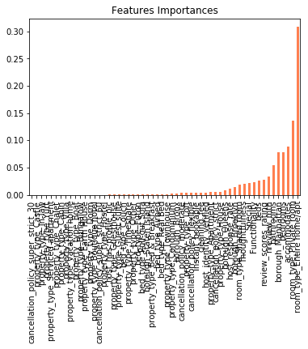

```python
importances = pd.Series(data=rf3.feature_importances_, index= X_train.columns)
importances = importances.sort_values()
importances.plot(kind='bar', color='coral')
plt.title('Features Importances')
plt.show()
```

```python
importances
```

```
cancellation_policy_super_strict_30    0.000000
property_type_Castle                   0.000000
property_type_In-law                   0.000002
property_type_Yurt                     0.000002
property_type_Serviced apartment       0.000002
property_type_Chalet                   0.000003
property_type_Cabin                    0.000005
property_type_Villa                    0.000010
property_type_Vacation home            0.000011
property_type_Boat                     0.000029
property_type_Bungalow                 0.000053
property_type_Earth House              0.000053
property_type_Dorm                     0.000059
property_type_Boutique hotel           0.000059
cancellation_policy_super_strict_60    0.000061
property_type_Hostel                   0.000066
host_has_profile_pic                   0.000104
property_type_Guesthouse               0.000160
property_type_Guest suite              0.000160
bed_type_Couch                         0.000223
property_type_Timeshare                0.000513
property_type_Other                    0.000554
bed_type_Futon                         0.000622
bed_type_Pull-out Sofa                 0.000724
borough_Staten Island                  0.000728
property_type_Bed & Breakfast          0.000760
bed_type_Airbed                        0.000877
bed_type_Real Bed                      0.001423
property_type_Townhouse                0.001548
property_type_Condominium              0.001803
borough_Bronx                          0.002797
cancellation_policy_moderate           0.003369
property_type_Loft                     0.003903
cancellation_policy_flexible           0.004084
instant_bookable                       0.004280
cleaning_fee                           0.004407
host_identity_verified                 0.004425
property_type_Apartment                0.004550
cancellation_policy_strict             0.004656
property_type_House                    0.005441
borough_Queens                         0.008005
host_response_rate                     0.010993
borough_Brooklyn                       0.014015
room_type_Shared room                  0.019161
Thoughtfulness                         0.020321
Special                                0.021486
Functionality                          0.023492
beds                                   0.025463
review_scores_rating                   0.027965
nreview_mth                            0.034159
bathrooms                              0.054056
borough_Manhattan                      0.077482
bedrooms                               0.078478
accommodates                           0.088278
room_type_Private room                 0.136102
room_type_Entire home/apt              0.308018
dtype: float64
```

```python
from sklearn.feature_selection import SelectFromModel
thrsd = []
MSE = []
test_score = []
for threshold in np.arange(0.000001,0.00003,0.000001):
    thrsd.append(threshold)
    sfm = SelectFromModel(rf3, threshold)
    # Train the selector
    sfm.fit(X_train_scaled, y_train)
    X_important_train = sfm.transform(X_train_scaled)
    X_important_test = sfm.transform(X_test_scaled)
    clf_important = RandomForestRegressor(max_depth=14,max_features=20,n_estimators=200)
    clf_important.fit(X_important_train, y_train)
    y_pred = clf_important.predict(X_important_test)
    MSE.append(mean_squared_error(y_test,y_pred))
    test_score.append(clf_important.score(X_important_test,y_test))
```

```python
# pick the thrsd for the highest score
thrsd[test_score.index(max(test_score))]
```

```
1.9999999999999998e-05
```

```python
# the thrsd for lowest MSE
thrsd[MSE.index(min(MSE))]
```

```
1.9999999999999998e-05
```

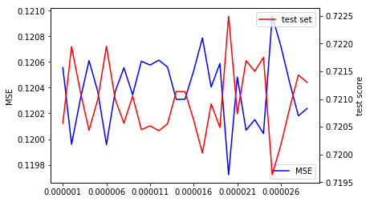

```python
fig = plt.figure()
ax1 = fig.add_subplot(111)
ax1.plot(thrsd, MSE, 'b', label='MSE')
ax1.set_ylabel('MSE')
ax1.legend(loc='lower right')
ax2 = ax1.twinx()
ax2.plot(thrsd, test_score, 'r', label='test set')
ax2.set_ylabel('test score')
ax2.legend(loc='upper right')
plt.xlabel('threshold')
plt.xticks(np.arange(1e-06, 3e-05, step=5e-06))
plt.show()
```

```python
# final model, pick the threshold: 2e-05
threshold = 2e-05
sfm = SelectFromModel(rf3, threshold)
# Train the selector
sfm.fit(X_train_scaled, y_train)
X_important_train = sfm.transform(X_train_scaled)
X_important_test = sfm.transform(X_test_scaled)
clf_important = RandomForestRegressor(max_depth=14,max_features=20,n_estimators=200)
clf_important.fit(X_important_train, y_train)
y_pred = clf_important.predict(X_important_test)
mse = mean_squared_error(y_test, y_pred)
print("mse: {}".format(mse))
print("Accuracy on train set: {}".format(clf_important.score(X_important_train,y_train)))
print("Accuracy on test set: {}".format(clf_important.score(X_important_test, y_test)))
```

```
mse: 0.11994516812891272
Accuracy on train set: 0.8412344715091479
Accuracy on test set: 0.7219783280788712
```

### Cross validation

```python
# use the model after feature selection
from sklearn.model_selection import cross_validate
cv_results = cross_validate(clf_important, X_important_train, y_train, cv=5, return_train_score=False)
```

```python
cv_results['test_score']
```

```
array([0.7091015 , 0.69503186, 0.70325778, 0.67378544, 0.67943566])
```

```python
# the rf3 model using scaling
cv_rf3 = cross_validate(rf3, X_train_scaled, y_train, cv=5, return_train_score=False)
cv_rf3['test_score']
```

```
array([0.71047569, 0.69577852, 0.7042721 , 0.67468478, 0.68064359])
```

```python
# rf2 model without scaling
cv_rf2 = cross_validate(rf2, X_train_scaled, y_train, cv=5, return_train_score=False)
cv_rf2['test_score']
```

```
array([0.71096228, 0.69719828, 0.70427547, 0.67481566, 0.67989313])
```